# Transformations

J. Ignacio Lucas Lledó

19/4/2020

```r
knitr::opts_chunk$set(echo = TRUE)
library(e1071)
library(Biostrings)
library(tidyr)
```

```r
library(ggplot2)
library(plyr)
load('../2020-02-11/taxonomy.RData')
```

Here, I want to evaluate different transformations of abundance data, with the main goal of reducing skewness. For a principal component analysis (PCA), it is not strictly required to have multinormality, but skewness should be avoided [@Legendre2012, p. 411].

Below I prepare the two amplicon abundance matrices, `EA` and `LA`, for early and late abundances respectively. The amplicons (columns) are given a short name, and replicates of the same isoline are added, so that only 24 rows are left.

```r
# I use the taxa matrix to name amplicons, to be consistent with previous scripts.
dna <- DNAStringSet(row.names(taxa))
names(dna) <- sprintf("A%04i", seq(dim(taxa)[1]))
row.names(taxa)        <- names(dna)[match(row.names(taxa), dna)]
colnames(SeqTabNoChim) <- names(dna)[match(colnames(SeqTabNoChim), dna)]
SampleData <- data.frame(
  age = factor(substr(row.names(SeqTabNoChim), 1, 1), levels=c('E','L'), labels=c('Early','Late')),
  isoline = factor(stringr::str_extract(rownames(SeqTabNoChim), "[[:digit:]]+"),
                   levels=as.character(c(6,10,11,12,14,15,17,19,20,22,23,24,25,26,27,28,29,30,31,33,35,36,38,39)),
                   ordered=FALSE),
  replicate = gsub("([EL][[:digit:]]+|.fastq.gz)", "", rownames(SeqTabNoChim))
)
# Not using seqrun here.

row.names(SampleData) <- row.names(SeqTabNoChim)

isEarly <- SampleData$age == 'Early'
isLate  <- SampleData$age == 'Late'
EarlyAbundance <- SeqTabNoChim[isEarly,]
LateAbundance  <- SeqTabNoChim[isLate,]
EarlyIsoline <- SampleData[isEarly, 'isoline']
LateIsoline  <- SampleData[isLate,  'isoline']
# I found it impossible to do the following with plyr:
EA <- do.call(rbind, lapply(split(as.data.frame(EarlyAbundance), EarlyIsoline), colSums))
LA <- do.call(rbind, lapply(split(as.data.frame(LateAbundance),  LateIsoline),  colSums))
rm(EarlyAbundance, LateAbundance, EarlyIsoline, LateIsoline, isEarly, isLate, SeqTabNoChim)
```

Absolute abundances must be turned into relative abundances. Otherwise, abundances are not dimensionally homogeneous across isolines, because of varying sequencing efforts. Then, I can use prevalence and average abundance to filter amplicons. Removing the rarest amplicons does not change the distribution of relative abundances of the remaining amplicons across isolines, but may eliminate some of the most skewed amplicons.

```r
EA.prop <- t(apply(EA, 1, function(x) x / sum(x)))
LA.prop <- t(apply(LA, 1, function(x) x / sum(x)))

AbundanceSummary <- data.frame(
  EA.meanProp = apply(EA.prop, 2, mean),
  LA.meanProp = apply(LA.prop, 2, mean),
  EA.prevalence = colSums(EA > 0),
  LA.prevalence = colSums(LA > 0)
)

EA.filter <- AbundanceSummary$EA.meanProp >= 5.0e-5 & AbundanceSummary$EA.prevalence >= 5
LA.filter <- AbundanceSummary$LA.meanProp >= 5.0e-5 & AbundanceSummary$LA.prevalence >= 5

EA.high <- EA.prop[,EA.filter]
LA.high <- LA.prop[,LA.filter]

colnames(EA.high) <- paste0('E', colnames(EA.high))
colnames(LA.high) <- paste0('L', colnames(LA.high))
A <- cbind(EA.high, LA.high)

Skew <- data.frame(Amplicon   = substr(colnames(A), 2, 6),
                   Age        = substr(colnames(A), 1, 1),
                   meanProp   = NA,
                   Prevalence = NA,
                   Relative   = apply(A, 2, skewness),
                   stringsAsFactors = FALSE)
Skew[Skew$Age == 'E', 'meanProp'] <- AbundanceSummary[Skew[Skew$Age == 'E','Amplicon'], 'EA.meanProp']
Skew[Skew$Age == 'L', 'meanProp'] <- AbundanceSummary[Skew[Skew$Age == 'L','Amplicon'], 'LA.meanProp']
Skew[Skew$Age == 'E', 'Prevalence'] <- AbundanceSummary[Skew[Skew$Age == 'E', 'Amplicon'], 'EA.prevalence']
Skew[Skew$Age == 'L', 'Prevalence'] <- AbundanceSummary[Skew[Skew$Age == 'L', 'Amplicon'], 'LA.prevalence']
```

The metric chi-square transformation was one of the transformations suggested by @Legendre2001 that produced some interesting non-Euclidean distances among original vectors when calculating the Euclidean distances among transformed vectors. The reasons to use such non-Euclidean distances I think had more to do with the double-zero problem than with skewness. Actually, the metric chi-square transformation does not reduce the skewness at all. What I need are non-linear transformations applied separately to each amplicon’s relative abundances.

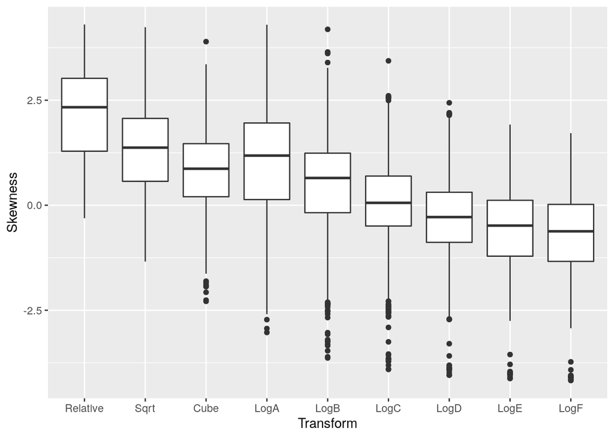

```r
A.sqrt <- sqrt(A)
A.cube <- A ^ (1/3)
A.logA <- log10(A + 1.0e-4)
A.logB <- log10(A + 1.0e-5)
A.logC <- log10(A + 1.0e-6)
A.logD <- log10(A + 1.0e-7)
A.logE <- log10(A + 1.0e-8)
A.logF <- log10(A + 1.0e-9)

Skew$Sqrt <- apply(A.sqrt, 2, skewness)
Skew$Cube <- apply(A.cube, 2, skewness)
Skew$LogA <- apply(A.logA, 2, skewness)
Skew$LogB <- apply(A.logB, 2, skewness)
Skew$LogC <- apply(A.logC, 2, skewness)
Skew$LogD <- apply(A.logD, 2, skewness)
Skew$LogE <- apply(A.logE, 2, skewness)
Skew$LogF <- apply(A.logF, 2, skewness)

SkewLong <- pivot_longer(Skew, cols=5:13, names_to='Transform', values_to='Skewness')
SkewLong$Transform <- factor(SkewLong$Transform,
                             levels=c('Relative','Sqrt','Cube','LogA','LogB','LogC','LogD','LogE','LogF'),
                             ordered = TRUE)
ggplot(SkewLong, aes(x=Transform, y=Skewness)) + geom_boxplot()
```

The logarithmic transformation with an added constant of 1e-6 successfully reduces the skewness for most amplions, but makes some amplicons much more (left) skewed than they were before. Those are relatively prevalent amplicons, which did not even require much of a transformation in the first place.

Here I have applied the same basic transformation to all descriptors, because all of them are the same kind of data, and it makes interpretation easier. It is also possible to apply a different transformation (or none) to different amplicons. It could even make biological sense that some amplicons affect some life-history traits in a linear fashion, while other have an exponential effect. However, I have no *a priori* reason to treat different amplicons differently. After transformation, only a few become too negatively skewed. Even though they are among the most abundant amplicons, not all the abundant amplicons are negatively affected by the logarithmic transformation. I think the most reasonable option is to remove from the analysis the amplicons the abundance distribution of which are too skewed after transformation. Setting the thresholds at -1 and 1 would leave 434 amplicons in early life, and 318 in late life.